# Project visualisation

Kamel, Abderrahim

12/03/2020

## R Markdown

Chargement de nos données ’Données_météo.csv` Les données date de 18/03/2020 à 12h40

```r
library(readr)
library(rgrs)
data_weather <- read_csv("Données_météo.csv")
data_weather$country <- as.factor(data_weather$country)
data_weather$name <- as.factor(data_weather$name)
data_weather$continent <- as.factor(data_weather$continent)
```

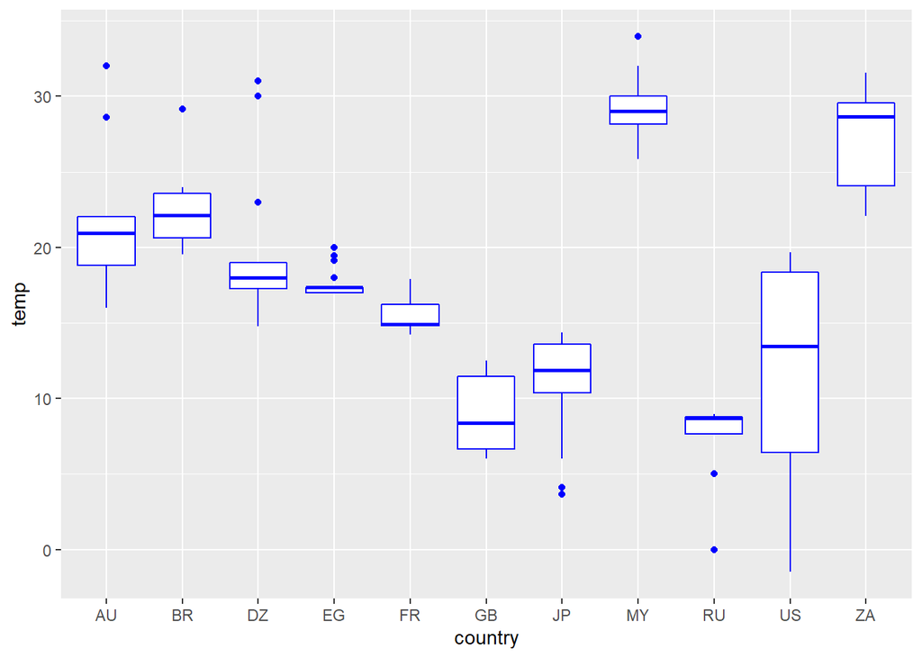

```r
library(ggplot2)
ggplot(data_weather, aes(x=country , y=temp)) + geom_boxplot(color="blue")
```

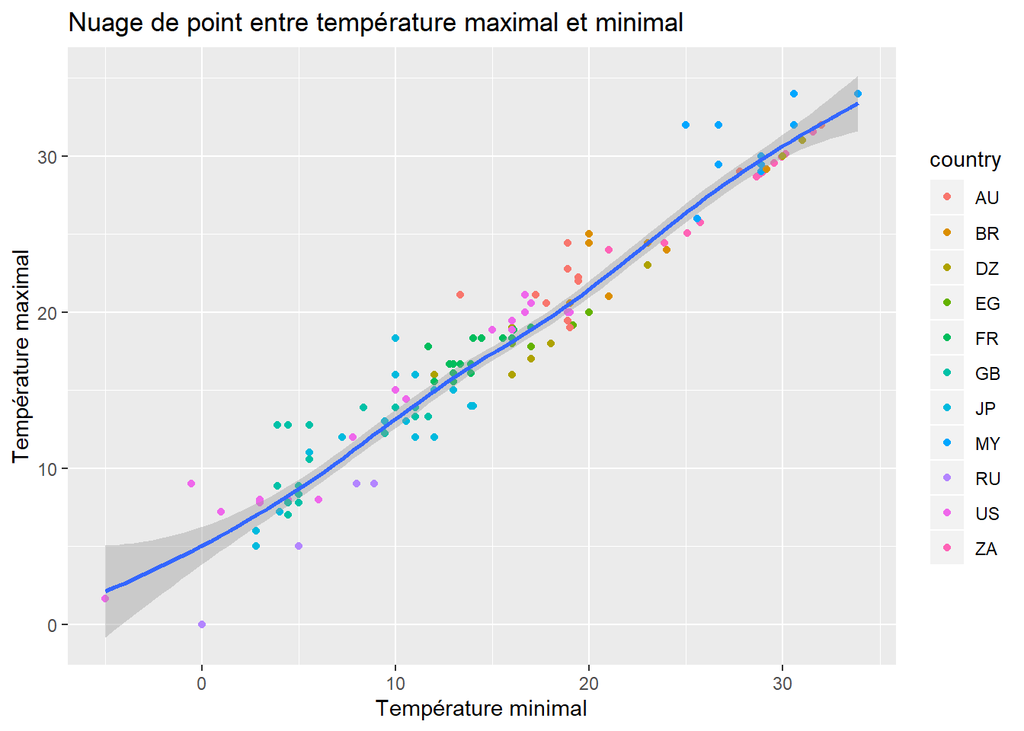

```r
library(ggplot2)
ggplot(data_weather, aes(x=temp_min , y=temp_max)) + geom_point(aes(color=country)) + geom_smooth() +
  ggtitle("Nuage de point entre température maximal et minimal") +
  xlab("Température minimal") +
  ylab("Température maximal")
```

On voit qu’il y’a une corrélaion entre Température minimal et maximal on voit aussi qu’il ya pas une grade marge d’ereur jsue un peur au début de vu que il ya pas bcp d’information

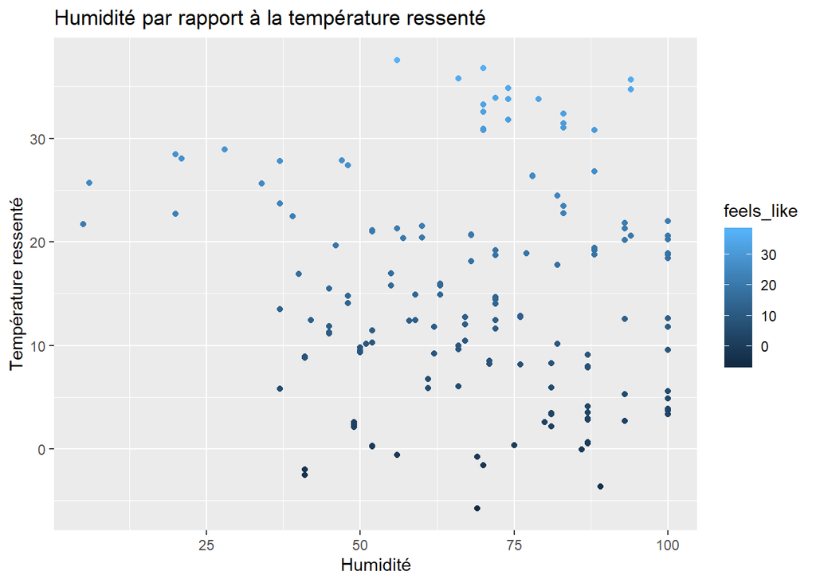

```r
library(ggplot2)
ggplot(data_weather, aes(x=humidity , y=feels_like )) + geom_point(aes(color=feels_like)) +
  ggtitle("Humidité par rapport à la température ressenté") +
  xlab("Humidité") +
  ylab("Température ressenté")
```

```r
library(dplyr)
```

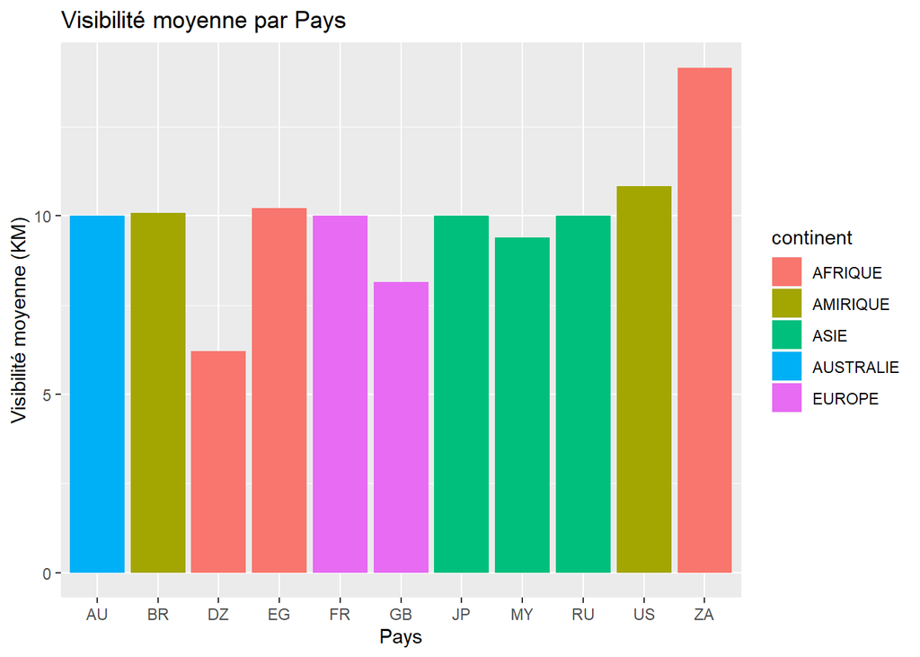

```r
library(ggplot2)

by_country <- group_by(data_weather, country, continent)
country1<-summarise(by_country, visibility = mean(visibility))

ggplot(country1, aes(country, visibility)) + geom_col(aes(fill=continent)) +
  ggtitle("Visibilité moyenne par Pays") +
  xlab("Pays") +
  ylab("Visibilité moyenne (KM)")
```

Ce graphe nous montre la Visibilité moyenne pas Pays et regrouper par Continent on voit que la plupart des pays ont une visibilité moyenne de 10 KM. On remarque que dans le même Continent on trouve L’Algrerie avec une faible visibilité qui est a 6 KM et Afric de sud avec une visibilité plus élevé presque 14 KM

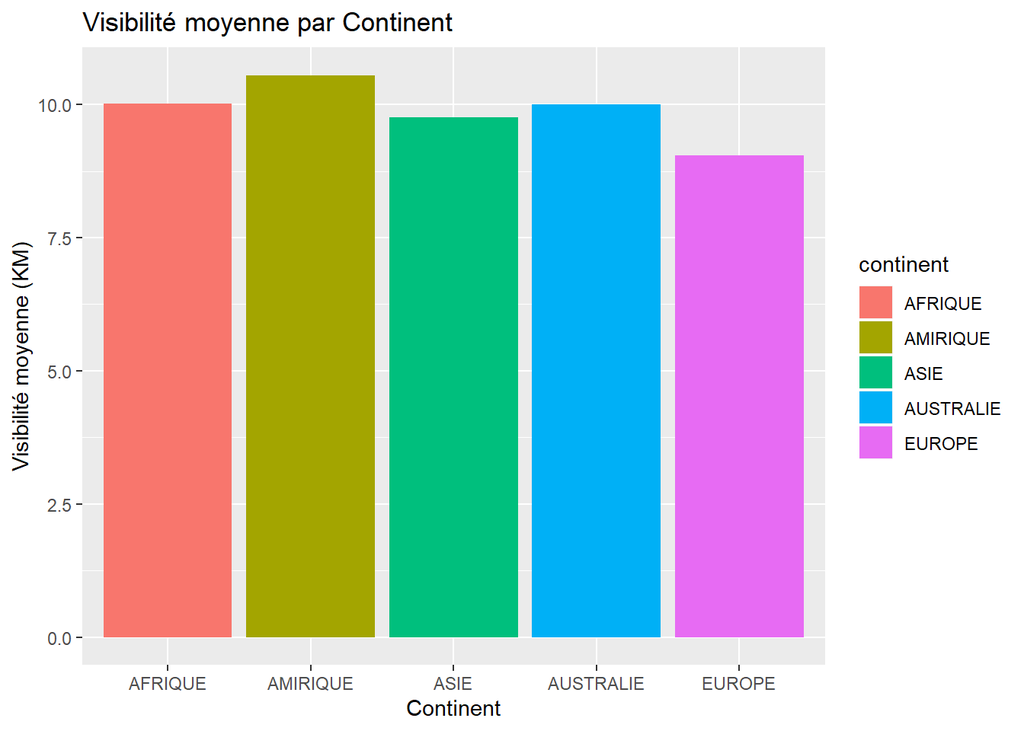

```r
library(dplyr)
library(ggplot2)

by_country <- group_by(data_weather, continent)
country1<-summarise(by_country, visibility = mean(visibility))

ggplot(country1, aes(continent, visibility)) + geom_col(aes(fill=continent)) +
  ggtitle("Visibilité moyenne par Continent") +
  xlab("Continent") +
  ylab("Visibilité moyenne (KM)")
```

Ce graphe nous montre la Visibilité moyenne par Continent On voit qu’il y a pas beaucoup de différence entre les continent

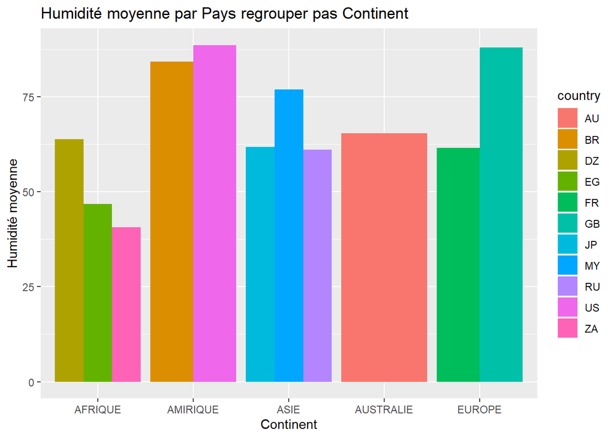

```r
library(dplyr)
library(ggplot2)

by_continent <- group_by(data_weather, continent, country)
dt_continent<-summarise(by_continent, humidity = mean(humidity))

ggplot(dt_continent, aes(continent, humidity)) + geom_col(aes(fill=country), position = "dodge") +
  ggtitle("Humidité moyenne par Pays regrouper pas Continent") +
  xlab("Continent") +
  ylab("Humidité moyenne")
```

Ce graphe nous montre l’Humidité moyenne pas Pays et regrouper par Continent Ce graphe nous permet comparer l’Humidité moyenne entres les pays

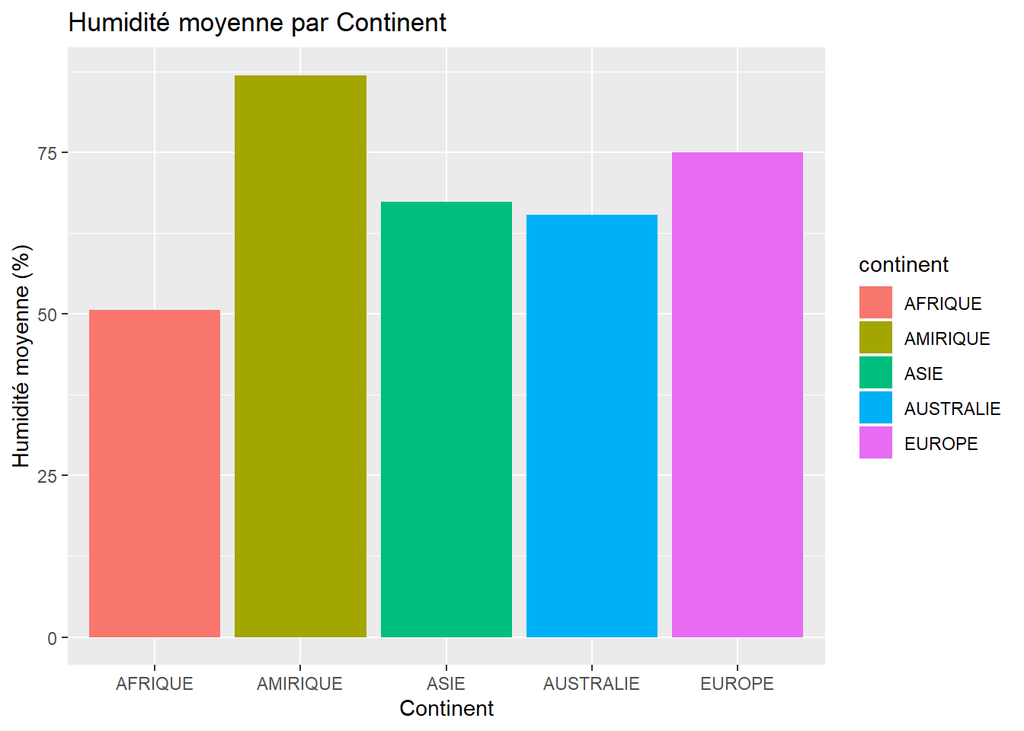

```r
library(dplyr)
library(ggplot2)

by_country <- group_by(data_weather, continent)
country1<-summarise(by_country, humidity = mean(humidity))

ggplot(country1, aes(continent, humidity)) + geom_col(aes(fill=continent)) +
  ggtitle("Humidité moyenne par Continent") +
  xlab("Continent") +
  ylab("Humidité moyenne (%)")
```

Ce graphe nous montre l’Humidité moyenne pas Continent On voit que le Continent Américain a une Humidité plus élevé avec 87%, aprés c’est l’Europe avec 75% et en dernier Arfique avec 50%.

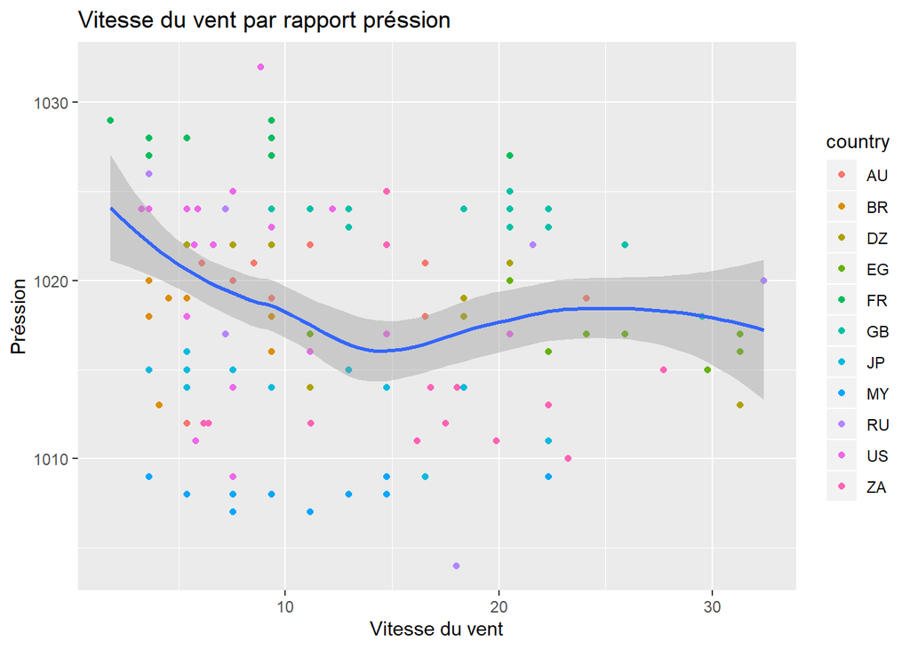

```r
library(ggplot2)
ggplot(data_weather, aes(x=speed , y=pressure)) + geom_point(aes(color=country)) + geom_smooth() +
  ggtitle("Vitesse du vent par rapport préssion ") +
  xlab("Vitesse du vent") +
  ylab("Préssion")
```

Dans ce Graphe on a voulu voir s’il ya une relation ou une corrélation entre le vent et la pression atmosphérique D’aprés les resultat qu’on voit sur graphe on voit pas une corrélation et même on peut pas deduire une relation entre ces 2 élément.